# Prosper Loan Data Exploration by Yeqing Zhang

```r
# number of observations and columns of dataset
dim(df)
```

```
## [1] 113937     81
```

```r
# summary of dataset
summary(df)
```

```
##                    ListingKey     ListingNumber
##  17A93590655669644DB4C06:     6   Min.   :      4
##  349D3587495831350F0F648:     4   1st Qu.: 400919
##  47C1359638497431975670B:     4   Median : 600554
##  8474358854651984137201C:     4   Mean   : 627886
##  DE8535960513435199406CE:     4   3rd Qu.: 892634
##  04C13599434217079754AEE:     3   Max.   :1255725
##  (Other)                :113912
##                     ListingCreationDate  CreditGrade         Term
##  2013-10-02 17:20:16.550000000:     6          :84984   Min.   :12.00
##  2013-08-28 20:31:41.107000000:     4   C      : 5649   1st Qu.:36.00
##  2013-09-08 09:27:44.853000000:     4   D      : 5153   Median :36.00
##  2013-12-06 05:43:13.830000000:     4   B      : 4389   Mean   :40.83
##  2013-12-06 11:44:58.283000000:     4   AA     : 3509   3rd Qu.:36.00
##  2013-08-21 07:25:22.360000000:     3   HR     : 3508   Max.   :60.00
##  (Other)                      :113912   (Other): 6745
##                  LoanStatus                  ClosedDate
##  Current              :56576                      :58848
##  Completed            :38074   2014-03-04 00:00:00:  105
##  Chargedoff           :11992   2014-02-19 00:00:00:  100
##  Defaulted            : 5018   2014-02-11 00:00:00:   92
##  Past Due (1-15 days) :  806   2012-10-30 00:00:00:   81
##  Past Due (31-60 days):  363   2013-02-26 00:00:00:   78
##  (Other)              : 1108   (Other)            :54633
##   BorrowerAPR       BorrowerRate     LenderYield
##  Min.   :0.00653   Min.   :0.0000   Min.   :-0.0100
##  1st Qu.:0.15629   1st Qu.:0.1340   1st Qu.: 0.1242
##  Median :0.20976   Median :0.1840   Median : 0.1730
##  Mean   :0.21883   Mean   :0.1928   Mean   : 0.1827
##  3rd Qu.:0.28381   3rd Qu.:0.2500   3rd Qu.: 0.2400
##  Max.   :0.51229   Max.   :0.4975   Max.   : 0.4925
##  NA's   :25
##  EstimatedEffectiveYield EstimatedLoss   EstimatedReturn
##  Min.   :-0.183          Min.   :0.005   Min.   :-0.183
##  1st Qu.: 0.116          1st Qu.:0.042   1st Qu.: 0.074
##  Median : 0.162          Median :0.072   Median : 0.092
##  Mean   : 0.169          Mean   :0.080   Mean   : 0.096
##  3rd Qu.: 0.224          3rd Qu.:0.112   3rd Qu.: 0.117
##  Max.   : 0.320          Max.   :0.366   Max.   : 0.284
##  NA's   :29084           NA's   :29084   NA's   :29084
```

[output cut: 193 more lines]

```
##  Min.   :    0.00                Min.   :0.7000   Min.   : 0.00000
##  1st Qu.:    0.00                1st Qu.:1.0000   1st Qu.: 0.00000
##  Median :    0.00                Median :1.0000   Median : 0.00000
##  Mean   :   25.14                Mean   :0.9986   Mean   : 0.04803
##  3rd Qu.:    0.00                3rd Qu.:1.0000   3rd Qu.: 0.00000
##  Max.   :21117.90                Max.   :1.0125   Max.   :39.00000
##
##  InvestmentFromFriendsCount InvestmentFromFriendsAmount   Investors
##  Min.   : 0.00000           Min.   :    0.00            Min.   :   1.00
##  1st Qu.: 0.00000           1st Qu.:    0.00            1st Qu.:   2.00
##  Median : 0.00000           Median :    0.00            Median :  44.00
##  Mean   : 0.02346           Mean   :   16.55            Mean   :  80.48
##  3rd Qu.: 0.00000           3rd Qu.:    0.00            3rd Qu.: 115.00
##  Max.   :33.00000           Max.   :25000.00            Max.   :1189.00
##
```

```r
# print out the column types
str(df)
```

```
## 'data.frame':    113937 obs. of  81 variables:
##  $ ListingKey                         : Factor w/ 113066 levels "00003546482094282EF90E5",..: 7180 7193 6647 6669 6686 6689 6699 6706 6687 6687 ...
##  $ ListingNumber                      : int  193129 1209647 81716 658116 909464 1074836 750899 768193 1023355 1023355 ...
##  $ ListingCreationDate                : Factor w/ 113064 levels "2005-11-09 20:44:28.847000000",..: 14184 111894 6429 64760 85967 100310 72556 74019 97834 97834 ...
##  $ CreditGrade                        : Factor w/ 9 levels "","A","AA","B",..: 5 1 8 1 1 1 1 1 1 1 ...
##  $ Term                               : int  36 36 36 36 36 60 36 36 36 36 ...
##  $ LoanStatus                         : Factor w/ 12 levels "Cancelled","Chargedoff",..: 3 4 3 4 4 4 4 4 4 4 ...
##  $ ClosedDate                         : Factor w/ 2803 levels "","2005-11-25 00:00:00",..: 1138 1 1263 1 1 1 1 1 1 1 ...
##  $ BorrowerAPR                        : num  0.165 0.12 0.283 0.125 0.246 ...
##  $ BorrowerRate                       : num  0.158 0.092 0.275 0.0974 0.2085 ...
##  $ LenderYield                        : num  0.138 0.082 0.24 0.0874 0.1985 ...
##  $ EstimatedEffectiveYield            : num  NA 0.0796 NA 0.0849 0.1832 ...
##  $ EstimatedLoss                      : num  NA 0.0249 NA 0.0249 0.0925 ...
##  $ EstimatedReturn                    : num  NA 0.0547 NA 0.06 0.0907 ...
##  $ ProsperRating..numeric.            : int  NA 6 NA 6 3 5 2 4 7 7 ...
```

[output cut: 67 more lines]

# Univariate Plots Section

## Prosper Score

```
## stat_bin: binwidth defaulted to range/30. Use 'binwidth = x' to adjust this.
```

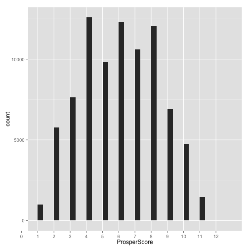

The Prosper Score seems to be mostly from 4 to 8. The score with the largest population is 4.

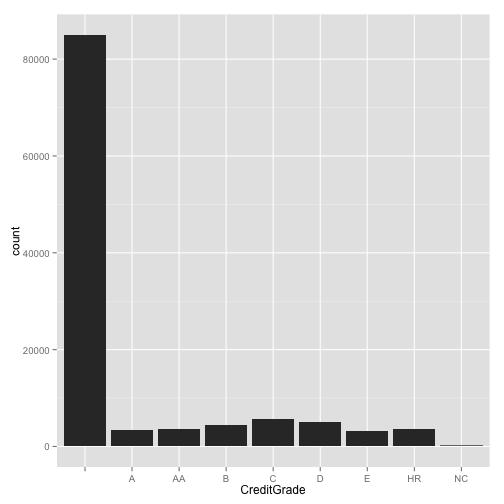

There are quite a lot of missing values (empty values) in the credit grade.

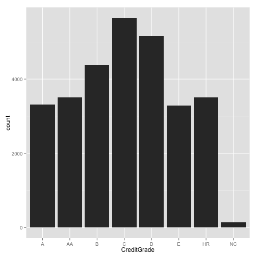

After removing the missing category, it is shown that the number of loans increases with decrease of CreditGrade until “C”. Then it drops with decrease of CreditGrade. There are very few loans with CreditGrade of “NC”. Why dont't people tend to borrow loans with the highest CreditGrade “A”, but rather a medium level “C”?

## Loan Amount

```
##    Min. 1st Qu.  Median    Mean 3rd Qu.    Max.
##    1000    4000    6500    8337   12000   35000
```

The median value for the original loan amount is 6500, mean value is 8337.

```
## stat_bin: binwidth defaulted to range/30. Use 'binwidth = x' to adjust this.
```

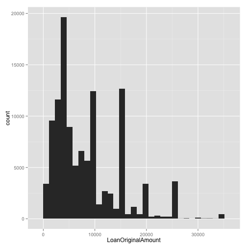

It is noticed that the majority of the loans have below 10000. And it seems that the distribution is multi-modal, with multiple peaks at 4500, 10000, 15000, 20000, 25000. Let's transform the plot into a better understandable plot.

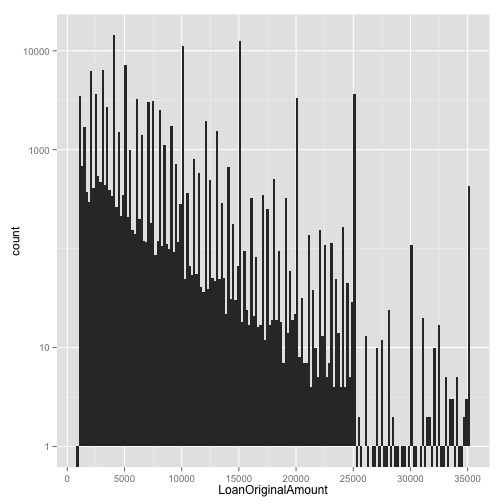

It shows that with the increase of LoanOriginalAmount, number of loans decreases. Also, there are quite a few spikes above the normal trend which indicates the distribution is quite sparse, with most of loans with amount at times of 5000. There are very few loans with original amount over 25000.

## Income

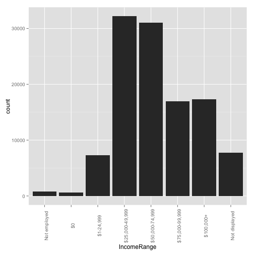

Most of the borrowers have annual income range of $25K-$75K.

```
## stat_bin: binwidth defaulted to range/30. Use 'binwidth = x' to adjust this.
```

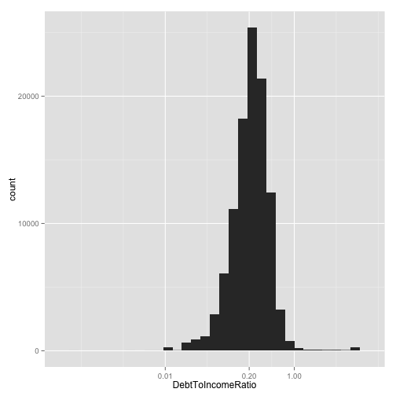

```r
summary(df$DebtToIncomeRatio)
```

```
##    Min. 1st Qu.  Median    Mean 3rd Qu.    Max.    NA's
##   0.000   0.140   0.220   0.276   0.320  10.010    8554
```

DebtToIncomeRatio shows a near-normal distribution on log scale, peaking at 0.2.

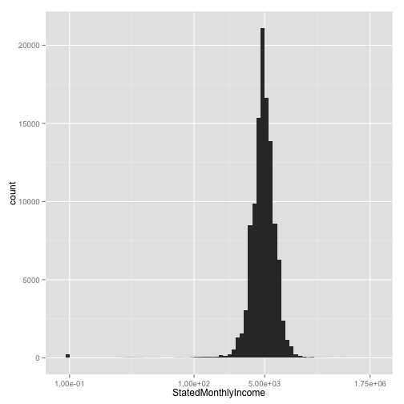

StatedMonthlyIncome presents a normal distribution on the log scale.

```r
summary(df$StatedMonthlyIncome)
```

```
##    Min. 1st Qu.  Median    Mean 3rd Qu.    Max.
##       0    3200    4667    5608    6825 1750000
```

The StatedMonthlyIncome's median is 4667 and mean value is 5608.

## Occupation and Employment

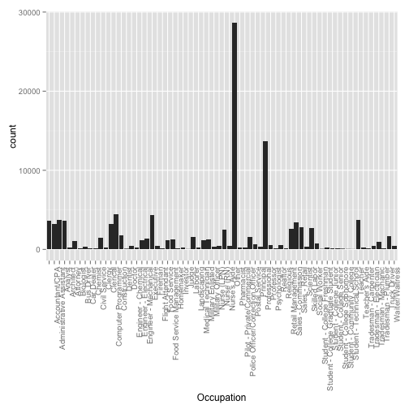

[figure not shown]

```r
qplot(x = Occupation, data = df) +
  # adjust the x label text to vertical direction
  theme(axis.text.x = element_text(angle = 90, hjust = 1))
```

The majority of the loans are from “Employed” and “Full-Time” browers.

## Interest Rate and Return

```
## stat_bin: binwidth defaulted to range/30. Use 'binwidth = x' to adjust this.
```

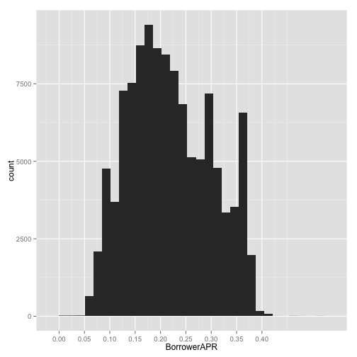

```r
qplot(x = BorrowerAPR, data = df) +
  scale_x_continuous(breaks = seq(0, 0.4, 0.05))
```

BorrowerAPR presents a distribution similar to a bell shape, peaking at around 0.18. There are also other 3 spikes at 0.09, 0.29, 0.37. Let's do a close look.

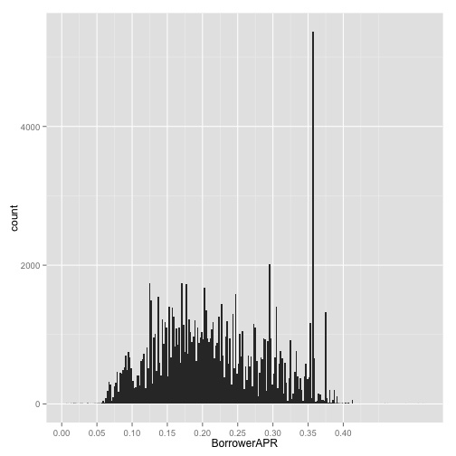

```r
qplot(x = BorrowerAPR, data = df, binwidth = 0.002) +
  scale_x_continuous(breaks = seq(0, 0.4, 0.05))
```

```
## stat_bin: binwidth defaulted to range/30. Use 'binwidth = x' to adjust this.
```

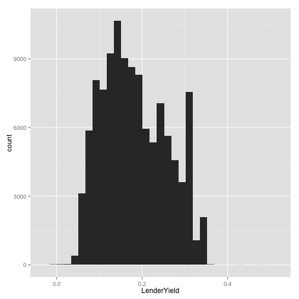

```r
qplot(x = LenderYield, data = df)
```

```
## stat_bin: binwidth defaulted to range/30. Use 'binwidth = x' to adjust this.
```

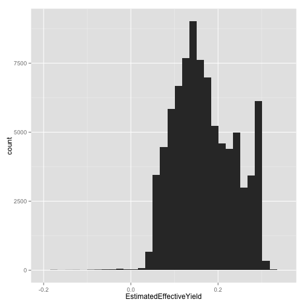

```r
qplot(x = EstimatedEffectiveYield, data = df)
```

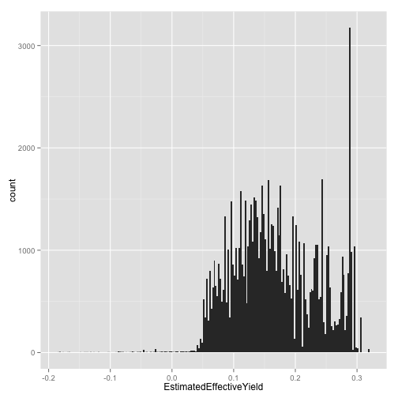

```r
qplot(x = EstimatedEffectiveYield, data = df, binwidth = 0.0025)
```

```
## stat_bin: binwidth defaulted to range/30. Use 'binwidth = x' to adjust this.
```

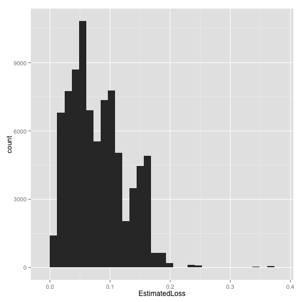

```r
qplot(x = EstimatedLoss, data = df)
```

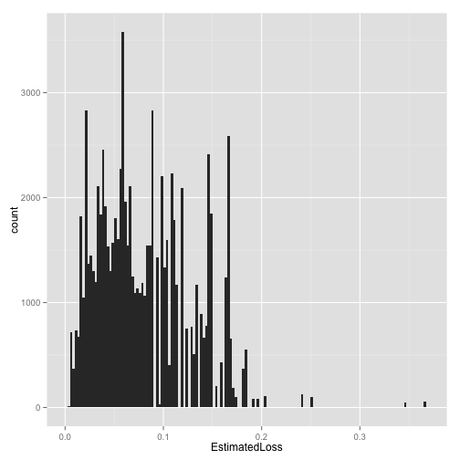

```r
qplot(x = EstimatedLoss, data = df, binwidth =0.0025)
```

```
## stat_bin: binwidth defaulted to range/30. Use 'binwidth = x' to adjust this.
```

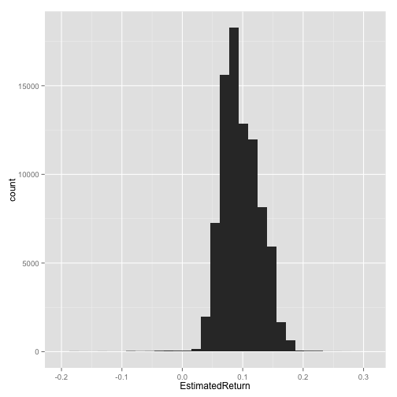

```r
qplot(x = EstimatedReturn, data = df)
```

It appears that the Estimated Return poses a normal distribution, peaking at 0.1 and with some values below 0.

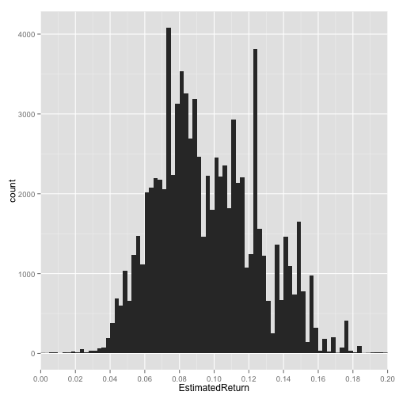

## Credit History

```
## stat_bin: binwidth defaulted to range/30. Use 'binwidth = x' to adjust this.
```

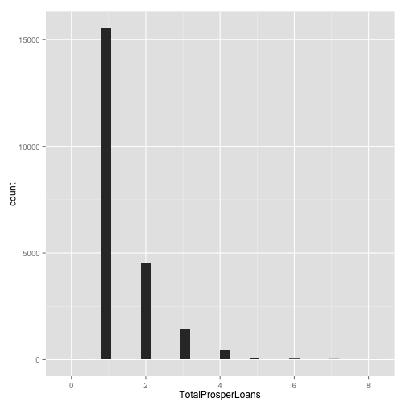

```r
qplot(x = TotalProsperLoans, data = df)
```

The number of loans appears to be exponentially decreasing with increase of TotalProsperLoans.

```r
summary(df$TotalProsperLoans)
```

```
##    Min. 1st Qu.  Median    Mean 3rd Qu.    Max.    NA's
##    0.00    1.00    1.00    1.42    2.00    8.00   91852
```

```r
print(paste('% NAs: ', sum(is.na(df$TotalProsperPaymentsBilled)) / nrow(df), ''))
```

```
## [1] "% NAs:  0.806164810377665 "
```

The summary shows there are 91852 NA values, about 80% of total observations. This means the majority of the borrowers are first-time borrowers on Prosper.

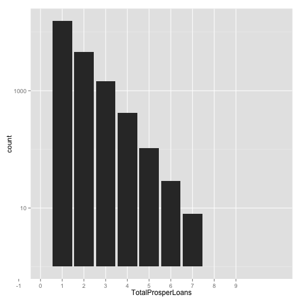

```r
qplot(x = TotalProsperLoans, data = subset(df, !is.na(TotalProsperLoans))) +
  scale_y_log10() +
  scale_x_discrete()
```

Above plot confirms the negative exponential relationship.

```
## stat_bin: binwidth defaulted to range/30. Use 'binwidth = x' to adjust this.
```

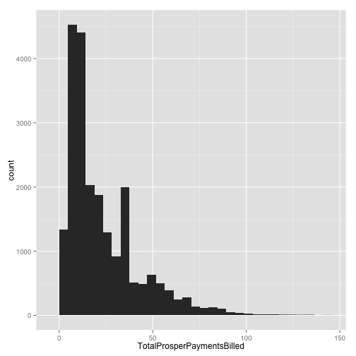

```r
qplot(x = TotalProsperPaymentsBilled, data = df)
```

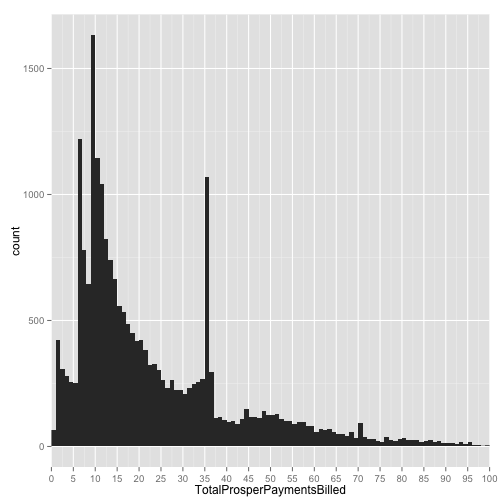

```r
qplot(x = TotalProsperPaymentsBilled, data = df,
      binwidth = 1) +
  scale_x_continuous(breaks = seq(0, 100, 5)) +
  coord_cartesian(xlim = c(0, 100))
```

The above plot shows that the payment bills seem to be quite strange. It seems to be consisted of a couple of exponential decreasing distributions starting from 1, 7, 11, 35. There is a prominent spike at 35.

```r
head(na.omit(df$TotalProsperPaymentsBilled), 1000)
```

[output not shown]

[output cut: 44 more lines]

```r
summary(df$TotalProsperPaymentsBilled)
```

```
##    Min. 1st Qu.  Median    Mean 3rd Qu.    Max.    NA's
##    0.00    9.00   16.00   22.93   33.00  141.00   91852
```

[output not shown]

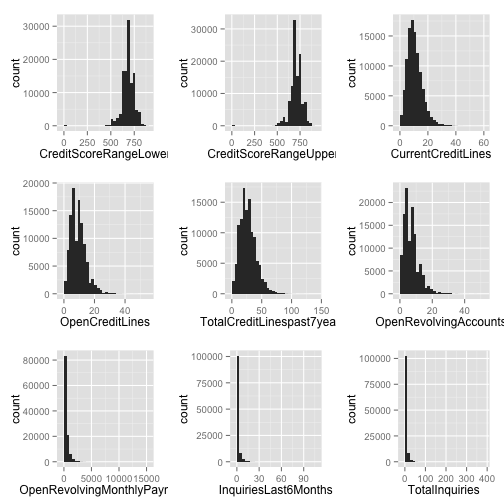

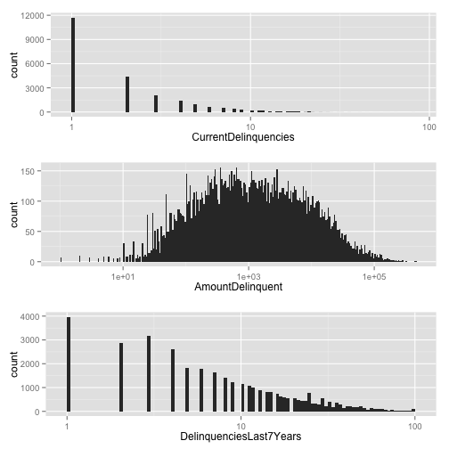

It shows that CurrentDelinquencies and DelinquenciesLast7Years present decreasing exponential distributions while AmountDelinquent presents a bell shape on log scale.

## Date

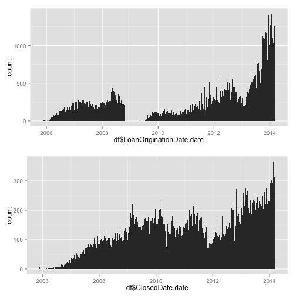

```r
p1 = qplot(df$LoanOriginationDate.date, binwidth = 7)
p2 = qplot(df$ClosedDate.date, binwidth = 7)

grid.arrange(p1, p2, ncol = 1)
```

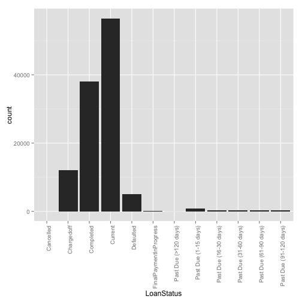

```
##
##              Cancelled             Chargedoff              Completed
##                      5                  11992                  38074
##                Current              Defaulted FinalPaymentInProgress
##                  56576                   5018                    205
##   Past Due (>120 days)   Past Due (1-15 days)  Past Due (16-30 days)
##                     16                    806                    265
##  Past Due (31-60 days)  Past Due (61-90 days) Past Due (91-120 days)
##                    363                    313                    304
```

```
##
##              Cancelled             Chargedoff              Completed
##           0.0000438839           0.1052511476           0.3341671274
##                Current              Defaulted FinalPaymentInProgress
##           0.4965551138           0.0440418828           0.0017992399
##   Past Due (>120 days)   Past Due (1-15 days)  Past Due (16-30 days)
##           0.0001404285           0.0070740848           0.0023258467
##  Past Due (31-60 days)  Past Due (61-90 days) Past Due (91-120 days)
##           0.0031859712           0.0027471322           0.0026681412
```

The majority of the loans are Current (50%) and 33% are completed. There are 4.4% of defaulted loans and 10.5% of charged-off loans.

# Univariate Analysis

### What is the structure of your dataset?

The dataset contains total 113,937 observations with 81 variables.

Interesting categorical variables:

- IncomeRange: $0, $1-24,999, $25,000-49,999, $50,000-74,999, $75,000-99,999, $100,000+, Not employed, Not displayed.
- EmploymentStatus: Employed, Full-time, Not available, Not employed, Other, Part-time, Retired, Self-employed
- LoanStatus: Cancelled, Chargedoff, Completed, Current, Defaulted, FinalPaymentInProgress, Past, Due, (>120, days), Past, Due, (1-15, days), Past, Due, (16-30, days), Past, Due, (31-60, days), Past, Due, (61-90, days), Past, Due, (91-120, days)

### What is/are the main feature(s) of interest in your dataset?

The most interesting feature is ProsperScore, EstimatedReturn, BorrowerAPR, LoanOriginalAmount because I'd like to create a preditive model that predicts the ProsperScore that informs the lender on a loan decision. I believe EstimatedReturn, BorrowerAPR, LoanOriginalAmount can be important indicators of the ProsperScore.

### What other features in the dataset do you think will help support your investigation into your feature(s) of interest?

I think three categories of variables will help predict the model I would like to create.

- Income: IncomeRange, DebtToIncomeRatio, StatedMonthlyIncome
- Employment: EmploymentStatus, Occupation
- Interest and Return: BorrowerAPR, LenderYield, EstimatedEffectiveYield, EstimatedLoss, EstimatedReturn
- Credit History: TotalProsperLoans, TotalProsperPaymentsBilled, CreditScoreRangeLower, CreditScoreRangeUpper, CurrentCreditLines, OpenCreditLines, TotalCreditLinespast7years, OpenRevolvingAccounts, OpenRevolvingMonthlyPayment, CurrentDelinquencies, AmountDelinquent, DelinquenciesLast7Years

### Of the features you investigated, were there any unusual distributions? Did you perform any operations on the data to tidy, adjust, or change the form of the data? If so, why did you do this?

In the historgram of TotalProsperLoans, I adjusted the Y Axis to log scale. This allows the negative exponential relationship to be better presented. StatedMonthlyIncome histogram's X Axis was adjusted to log scale in order to present its normal distribution.

I also adjusted the bin width for a few histograms including LoanOriginalAmount, EstimatedReturn, EstimatedLoss, BorrowerAPR. I did so because default binwidth from qplot is too large so that some of the finer patterns (such as spikes over times of 5000 of LoanOriginalAmount).

# Bivariate Plots Section

## Correlaion

```
##                             ProsperScore   BorrowerAPR   LenderYield
## ProsperScore                 1.000000000 -0.7756081832 -0.7568693207
## BorrowerAPR                 -0.775608183  1.0000000000  0.9933354234
## LenderYield                 -0.756869321  0.9933354234  1.0000000000
## EstimatedEffectiveYield     -0.722746101  0.7975218152  0.7925556235
## EstimatedLoss               -0.717750956  0.9153079884  0.9129083651
## EstimatedReturn             -0.526230487  0.7408701771  0.7594150419
## DebtToIncomeRatio           -0.188196543  0.1752669698  0.1711300152
## StatedMonthlyIncome          0.176385631 -0.1981553243 -0.1946869337
## TotalProsperLoans            0.068466164 -0.0494553437 -0.0491863786
## TotalProsperPaymentsBilled   0.045597505  0.0261556567  0.0251046567
## CreditScoreRangeLower        0.483291107 -0.7031465276 -0.6858133948
## CreditScoreRangeUpper        0.483291107 -0.7031465276 -0.6858133948
## CurrentCreditLines          -0.051972118  0.0236402185  0.0245897893
## OpenCreditLines             -0.027991537  0.0039527524  0.0054184901
## TotalCreditLinespast7years  -0.130740839  0.1013894315  0.1010506039
## OpenRevolvingAccounts        0.036237188 -0.0425180489 -0.0412906803
## OpenRevolvingMonthlyPayment -0.001285185  0.0005081251 -0.0005642008
## CurrentDelinquencies        -0.184801155  0.1999374629  0.1951766603
## AmountDelinquent            -0.073729852  0.0661589858  0.0621256703
## DelinquenciesLast7Years     -0.141045290  0.1709799691  0.1665368389
##                             EstimatedEffectiveYield EstimatedLoss
## ProsperScore                           -0.722746101  -0.717750956
## BorrowerAPR                             0.797521815   0.915307988
## LenderYield                             0.792555623   0.912908365
## EstimatedEffectiveYield                 1.000000000   0.579764141
## EstimatedLoss                           0.579764141   1.000000000
## EstimatedReturn                         0.811548399   0.432283571
## DebtToIncomeRatio                       0.185199666   0.151735903
## StatedMonthlyIncome                    -0.144907090  -0.184053781
## TotalProsperLoans                      -0.007421791  -0.035702291
## TotalProsperPaymentsBilled              0.011213550   0.045366434
## CreditScoreRangeLower                  -0.587233268  -0.649480807
## CreditScoreRangeUpper                  -0.587233268  -0.649480807
## CurrentCreditLines                      0.055681024   0.017747170
## OpenCreditLines                         0.043942319   0.000775706
## TotalCreditLinespast7years              0.106500038   0.095720279
## OpenRevolvingAccounts                  -0.003185943  -0.047563091
## OpenRevolvingMonthlyPayment             0.043379178  -0.019428240
## CurrentDelinquencies                    0.150200026   0.210329006
```

[output cut: 197 more lines]

```
## EstimatedReturn                          0.10091213
## DebtToIncomeRatio                       -0.06632140
## StatedMonthlyIncome                     -0.03100907
## TotalProsperLoans                       -0.02753582
## TotalProsperPaymentsBilled               0.02293299
## CreditScoreRangeLower                   -0.20579584
## CreditScoreRangeUpper                   -0.20579584
## CurrentCreditLines                      -0.18059603
## OpenCreditLines                         -0.17855948
## TotalCreditLinespast7years               0.13835710
## OpenRevolvingAccounts                   -0.17003731
## OpenRevolvingMonthlyPayment             -0.17768441
## CurrentDelinquencies                     0.42058704
## AmountDelinquent                         0.30968027
## DelinquenciesLast7Years                  1.00000000
```

A quick preview of these correlation is plotted as below.

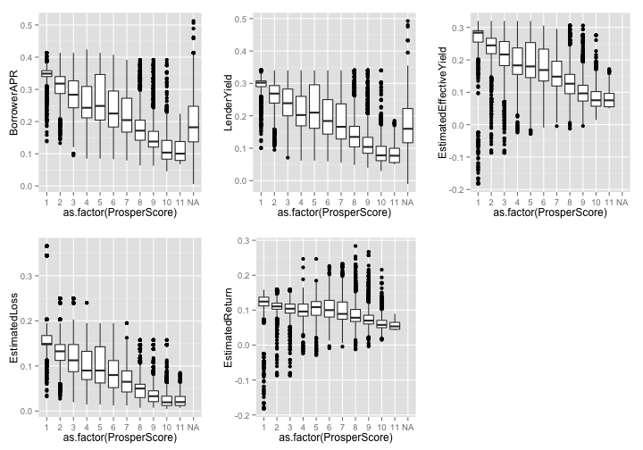

The boxplots visually present that ProsperScore is negatively correlated with BorrowerAPR, LenderYield, EstimatedEffectiveYield, EstimatedLoss, EstimatedReturn. This makes sense as it is intuitive for lenders to get higher return at higher risk (lower ProsperScore).

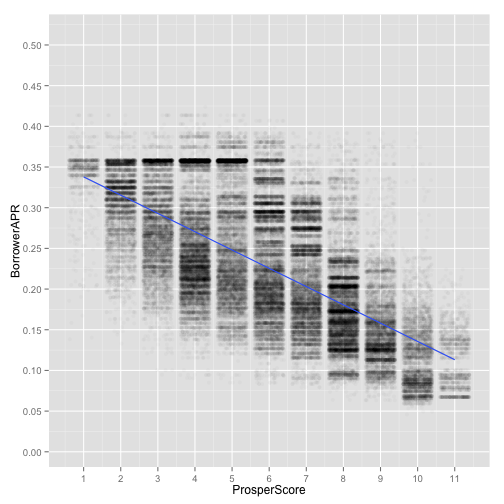

The overall BorrowerAPR posed a decreasing trend with increase of ProsperScore. However, it is noticed that there are a few dense area of BorrowerAPR around 0.36 for ProsperScore within 2-5. What are those loans and why they stay close to 0.36? I'd like to plot the histograms for each ProsperScore to highlight this pattern.

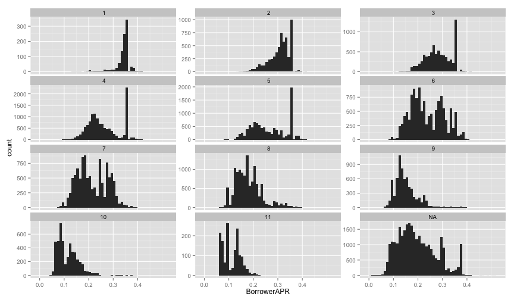

The above plots confirms that there are quite many loans (ProsperScore <= 5) are at BorrowerAPR ~ 0.35. What are they? Also, for loans with ProsperScore in 6-7, the BorrowersAPR distribution appears to be bimodal or multimodal peaking at 0.2 and 0.3.

```
##
##  0.3504  0.3505 0.35088  0.3509 0.35097 0.35118 0.35132 0.35169  0.3522
##       1       5       1      50      27       1     254       1       1
## 0.35244  0.3525  0.3527 0.35285 0.35356 0.35365 0.35372 0.35394 0.35423
##      69       1       1     214     656      11       1       1       7
## 0.35495 0.35602 0.35617 0.35643 0.35644 0.35654 0.35699 0.35772 0.35797
##       1       2       1    1531       1       7       2       1    3410
## 0.35811 0.35819 0.35838  0.3584 0.35842 0.35843 0.35858  0.3586 0.35879
##       1       1     117      15       1     101      66       1       1
## 0.35898  0.3593 0.36075 0.36113 0.36145 0.36158 0.36178 0.36207 0.36235
##       2       3       1       2       1       3       1       1       1
## 0.36275  0.3628 0.36336 0.36346 0.36421 0.36428 0.36438 0.36461 0.36548
##       1       4       1       1       1       1       9       1       1
## 0.36564 0.36574 0.36578 0.36666 0.36676 0.36697 0.36716 0.36844 0.36845
##       1       1       1       1       8       1       1       1       1
## 0.36895 0.36929 0.36937 0.36945  0.3696 0.36983
##       1       1       1       2       1       1
```